# PLSC30500, Fall 2024

Part 2. Summarizing distributions (part a)

Andy Eggers

# Expectations

## Motivation

Suppose we have a random variable $X$, e.g.

- number of heads in 3 coin flips,
- whether randomly selected voter plans to vote for Brexit
- income of randomly selected citizen

We know the PMF/PDF $f(x)$ and CDF $F(x)$.

How can we summarize this distribution?

## Expected value: discrete case

For discrete R.V. with probability mass function (PMF) $f(x)$, the *expected value* of $X$ is

$${\textrm E}\,[X] = \sum_x x f(x)$$

Could write

$${\textrm E}\,[X] = \sum_{x \in \text{Supp}[X]} x f(x)$$

## Example

| $x$ | $f(x)$ |
| --- | --- |
| 0 | .2 |
| 1 | .5 |
| 3 | .3 |

$$f(x) = \begin{cases} \,
.2 & x = 0 \\\
.5 & x = 1 \\\
.3 & x = 3 \\\
0 & \text{otherwise}
\end{cases}$$

What is ${\textrm E}\,[X] = \sum_x x f(x)$?

$$\begin{aligned}
{\textrm E}\,[X] &= 0 \times .2 + 1 \times .5 + 3 \times .3 \\
&= 1.4
\end{aligned}$$

## Same PMF

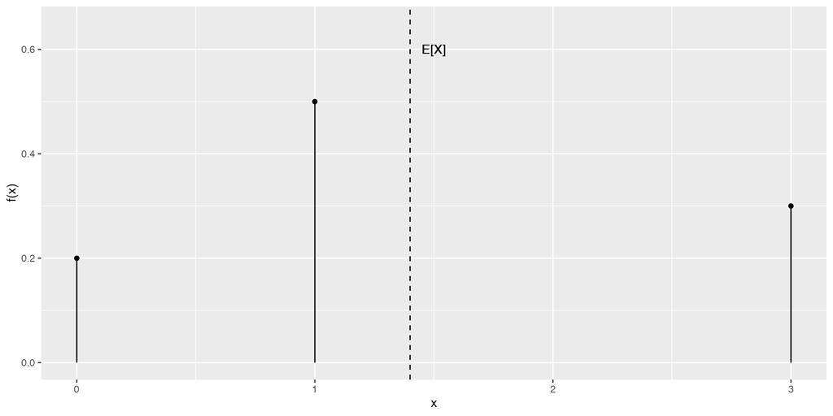

## Expectation vs average

You know about taking the **average** or **mean** of a set of numbers $x_1, x_2, \ldots, x_n$:

$$\overline{x} = \frac{1}{n} \sum_{i = 1}^n x_i$$

Just as a probability is a long-run frequency, an expectation is a long-run average.

- ${\textrm E}\,[X]$ summarizes a random variable $X$; $\overline{x}$ summarizes a set of numbers
- if each $x_i$ is an **independent sample** from $X$, $\overline{x}$ approximates ${\textrm E}\,[X]$ (more closely with larger samples)
- if each $x \in \text{Supp}[X]$ appears in the sample with frequency *exactly* $f(x)$, then $\overline{x} = {\textrm E}\,[X]$

## Expectation vs average (2)

Given PMF:

$$f(x) = \begin{cases} \,
.2 & x = 0 \\\
.5 & x = 1 \\\
.3 & x = 3 \\\
0 & \text{otherwise}
\end{cases}$$

Then ${\textrm E}\,[X] = 0 \times .2 + 1 \times .5 + 3 \times .3 = 1.4$.

Alternative method: make a vector of length $n$ where each $x$ appears $n f(x)$ times:

```r
x <- c(0, 0, 1, 1, 1, 1, 1, 3, 3, 3)
mean(x)
```

```
[1] 1.4
```

Why does this work?

## Expectation vs average (3)

If each unique $x$ appears $n f(x)$ times, then

$$\begin{aligned} \overbrace{\frac{1}{n} \sum_i x_i}^{\text{Average}} &= \frac{1}{n} \sum_x x n f(x) \\
&= \frac{n}{n} \sum_x x f(x) = {\textrm E}\,[X] \end{aligned}$$

May clarify why, in any given sample, $\overline{x} \neq {\textrm E}\,[X]$.

## The continuous case

For continuous R.V. $X$,

$${\textrm E}\,[X] = \int_{-\infty}^{\infty} x f(x) dx$$

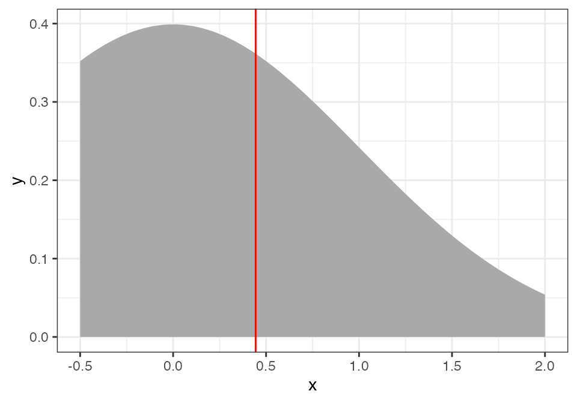

## ${\textrm E}\,[X]$ as a “good guess”

For R.V. $X$, consider $(X - c)^2$ for some constant $c$. (A function of a random variable.)

Define **mean squared error** of $X$ about $c$ as ${\textrm E}\,[(X - c)^2]$.

For $c=1$, we have:

| $x$ | $f(x)$ | $(x - 1)^2$ |
| --- | --- | --- |
| 0 | .2 | 1 |
| 1 | .5 | 0 |
| 3 | .3 | 4 |

${\textrm E}\,[X]$ is the choice of $c$ that minimizes MSE. (Wait for proof.)

## Bonus: ${\textrm E}\,[X]$ as X’s center of mass

Suppose we place a weight $f(x)$ at each value $x \in \text{Supp}(X)$ along a weightless rod.

Where is the **center of mass**, i.e. point where rod balances?

It is the point $c$ where $\sum_x (x - c) f(x) = 0$.

That point is ${\textrm E}\,[X]$.

**Proof**:

$$\begin{aligned} \sum_x (x - E[X]) f(x) &= \sum_x \left( x f(x) - E[X] f(x) \right) \\
&= \sum_x x f(x) - \sum_x E[X] f(x) \\
&= E[X] - E[X] \sum_x f(x) \\
&= E[X] - E[X] \\
&= 0
\end{aligned}$$

## Expectation of a function of two RVs

Consider this joint PMF $f(x, y)$ for $X$ and $Y$ (e.g. state 1 militarizes, state 2 militarizes)

| $x$ | $y$ | $f(x,y)$ |
| --- | --- | --- |
| 0 | 0 | 1/10 |
| 0 | 1 | 1/5 |
| 1 | 0 | 1/5 |
| 1 | 1 | 1/2 |

$$f(x,y) = \begin{cases} \,
1/10 & x = 0, y = 0 \\\
1/5 & x = 0, y = 1 \\\
1/5 & x = 1, y = 0 \\\
1/2 & x = 1, y = 1 \\\
0 & \text{otherwise}
\end{cases}$$

What is ${\textrm E}\,[XY]$? (will need e.g. for covariance)

$$\begin{aligned}
{\textrm E}\,[XY] &\equiv \sum_x \sum_y xy f(x, y) \\
&= 0 \times 1/10 + 0 \times 1/5 + 0 \times 1/5 + 1 \times 1/2 \\
&= 1/2
\end{aligned}$$

## Linearity of expectations

Let $X$ and $Y$ be RVs. Then $\forall a, b, c \in \mathbb{R}$, ${\textrm E}\,[aX + bY + c] = a{\textrm E}\,[X] + b{\textrm E}\,[Y] + c$

Proof (discrete case):

$$\begin{align}
{\textrm E}\,[aX + bY + c] &= \sum_x \sum_y (ax + by + c) f(x,y) \\
&= \sum_x \sum_y ax f(x,y) + \sum_x \sum_y by f(x,y) + \sum_x \sum_y c f(x,y) \\
&= a \sum_x \sum_y x f(x,y) + b \sum_x \sum_y y f(x,y) + c \sum_x \sum_y f(x,y) \\
&= a \sum_x x \sum_y f(x,y) + b \sum_y y \sum_x f(x,y) + c \sum_x \sum_y f(x,y) \\
&= a \sum_x x f_X(x) + b \sum_y y f_Y(y) + c \sum_x f_X(x)\\
&= a {\textrm E}\,[X] + b {\textrm E}\,[Y] + c
\end{align}$$

## Example of code interpretation

Consider this code:

```r
samp <- sample(x = c("a", "b", "c"),
               size = 1000,
               replace = T,
               prob = c(.1, .3, .6))
## R help file says:
# sample takes a sample of the specified size from the elements of x either with or without replacement.
## function arguments:
# x: either a vector of one or more elements from which to choose, or a positive integer.
# size: a non-negative integer giving the number of items to choose.
# replace: should sampling be with replacement?
# prob: a vector of probability weights for obtaining the elements of the vector being sampled.
tens <- rep(10, 1000)
```

What would the output of `mean(samp == "a")` be (approximately)?

**Answer**: It should be about .1, the probability of drawing an “a”.

What would the output of `sum(tens[samp == "b"])` be (approximately)?

**Answer**: It should be about $10 \times 300 = 3000$. (About 300 of the entries in `samp` should be “b”, so `tens[samp == "b]` should be a vector of about 300 10s, and the sum of this should be about 3000.)

# Variance

## Variance: definition and example

$${\textrm V}\,[X] \equiv {\textrm E}\,[(X - {\textrm E}\,[X])^2]$$

For Bernoulli RV ($x=1$ means heads, revolution?):

$$f(x) = \begin{cases}
1- p & x = 0 \\\
p & x = 1 \\\
0 & \text{otherwise}
\end{cases}$$

We can compute $(X - {\textrm E}\,[X])^2$ at each $x$:

| $x$ | $f(x)$ | $(x - {\textrm E}\,[X])^2$ |
| --- | --- | --- |
| 0 | $\color{green}{1-p}$ | $\color{red}{p^2}$ |
| 1 | $\color{blue}{p}$ | $\color{orange}{1 - 2p + p^2}$ |

And then variance as ${\textrm E}\,[(X - {\textrm E}\,[X])^2]$:

$$\begin{aligned}
{\textrm V}\,[X] &= {\textrm E}\,[(x - {\textrm E}\,[X])^2] \\ &= \color{red}{p^2}\color{green}{(1-p)} + \color{orange}{(1 - 2p + p^2)}\color{blue}{p} \\ &= p^2 - p^3 + p - 2p^2 + p^3 \\ &= p(1 - p)\end{aligned}$$

## Graphical example

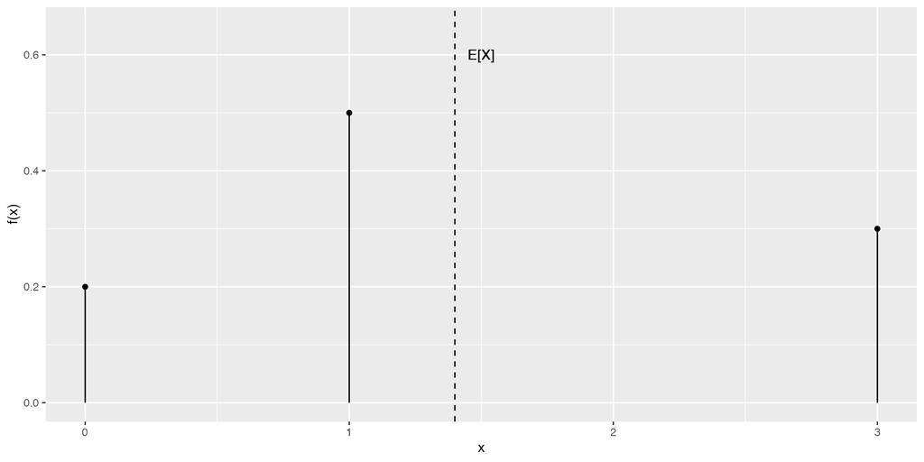

## Variance: alternative formulation

Bernoulli example again:

$$f(x) = \begin{cases}
1- p & x = 0 \\\
p & x = 1 \\\
0 & \text{otherwise}
\end{cases}$$

Alternative formulation for variance:

$${\textrm V}\,[X] = {\textrm E}\,[X^2] - {\textrm E}\,[X]^2$$

What is ${\textrm E}\,[X]$? What is ${\textrm E}\,[X^2]$?

By this alternative formula, we then have

$${\textrm V}\,[X] = p - p^2 = p(1-p)$$

## Proof that ${\textrm V}\,[X] = {\textrm E}\,[X^2] - {\textrm E}\,[X]^2$

$$\begin{align}
{\textrm V}\,[X] &= {\textrm E}\,\left[(X - {\textrm E}\,[X])^2\right] \\
&= {\textrm E}\,\left[X^2 - \color{blue}{2{\textrm E}\,[X]} X + {\textrm E}\,[X]^2\right] \\
&= {\textrm E}\,[X^2] - {\textrm E}\,\left[\color{blue}{2{\textrm E}\,[X]} X\right] + {\textrm E}\,\left[{\textrm E}\,[X]^2\right] \\
&= {\textrm E}\,[X^2] - \color{blue}{2{\textrm E}\,[X]} {\textrm E}\,[X] + {\textrm E}\,[X]^2 \\
&= {\textrm E}\,[X^2] - 2 {\textrm E}\,[X]^2 + {\textrm E}\,[X]^2 \\
&= {\textrm E}\,[X^2] - {\textrm E}\,[X]^2
\end{align}$$

## Properties of variance

For a random variable $X$,

- $\forall c \in \mathbb{R}$, ${\textrm V}\,[X + c] = {\textrm V}\,[X]$
- $\forall a \in \mathbb{R}$, ${\textrm V}\,[aX] = a^2{\textrm V}\,[X]$

Proof of first point:

$$\begin{align}
{\textrm V}\,[X + c] &= {\textrm E}\,\left[(X + c - {\textrm E}\,[X + c])^2\right] \\
&= {\textrm E}\,\left[(X + c - {\textrm E}\,[X] - {\textrm E}\,[c])^2\right] \\
&= {\textrm E}\,\left[(X + c - {\textrm E}\,[X] - c)^2\right] \\
&= {\textrm E}\,\left[(X - {\textrm E}\,[X])^2\right] \\
&= {\textrm V}\,[X]
\end{align}$$

## Standard deviation

Standard deviation:

$$\sigma[X] = \sqrt{{\textrm V}\,[X]}$$

Roughly, “how far does $X$ tend to be from its mean”?

## Revisiting justification for ${\textrm E}\,[X]$

Alternative formula for MSE:

$$\begin{align}
{\textrm E}\,[(X - c)^2] &= {\textrm E}\,\left[X^2 - 2cX + c^2\right] \\
&= {\textrm E}\,[X^2] - 2c{\textrm E}\,[X] + c^2 \\
&= {\textrm E}\,[X^2] - \color{red}{{\textrm E}\,[X]^2} + \color{green}{{\textrm E}\,[X]^2} - 2c{\textrm E}\,[X] + c^2 \\
&= \left({\textrm E}\,[X^2] - \color{red}{{\textrm E}\,[X]^2}\right) + \left(\color{green}{{\textrm E}\,[X]^2} - 2c{\textrm E}\,[X] + c^2\right) \\
&= {\textrm V}\,[X] + \left({\textrm E}\,[X] - c\right)^2
\end{align}$$

So what $c$ should you choose to minimize MSE?

## Parametric distributions

Given any RV $X$ with associated PMF/PDF or CDF, we can compute ${\textrm E}\,[X]$ and ${\textrm V}\,[X]$.

For special types of RV, these parameters *define* the distribution:

- Bernoulli distribution identified by ${\textrm E}\,[X]$ ($p$)
- Normal distribution identified by ${\textrm E}\,[X]$, ${\textrm V}\,[X]$ ($\mu$, $\sigma^2$)

But don’t get confused: any RV has ${\textrm E}\,[X]$ and ${\textrm V}\,[X]$, not just these special ones.

## Other things not to get confused about

Sometimes “mean” means ${\textrm E}\,[X]$ (e.g. *mean squared error* or $\mu$ of a normal distribution), sometimes it means “sample mean” or “average” of some numbers (e.g. `mean(c(2,4,6))`).

Sometimes “variance” means ${\textrm V}\,[X]$, sometimes it means “sample variance” (e.g. `var(c(2,4,6))`).

There is a close relationship, but remember that

- ${\textrm E}\,[X]$ and ${\textrm V}\,[X]$ are **operators** that convert a **distribution** (PMF, PDF, CDF) into a number, and
- `mean()` and `var()` are **`R` functions** that convert a **vector of numbers** (e.g. a sample) into a number.